# ANALYSE DES DONNEES RELATIVES A LA FIBROSE RETROPERITONEALE

Beogo Eric

11 septembre 2018

## ETUDE DE CORRELATION (test d’independance, anova)

Pour chaque variable, nous allons etudier l’independance entre les variables de la base et les traitements administrés. Le but est de connaitre les variables importantes Ã observé car variants selon le traitement.

Parmis nos variables, nous avons des variables qualitatives et des variables quantitatives. Pour les variables qualitatives nous effectuerons un test d’independance de khi2 : l’hypothese H0 etant etant que les variables d’etude sont independantss.On rejettera cet hypothese dans le seule cas où on aura une faible probabilité(la P_valeur) de l’accepter . pour les variables quantitatives nous ferons une analyse des variance et observerons la statistique du test de Fisher pour conclure.

# age

```
##                 Df Sum Sq Mean Sq F value Pr(>F)
## base$`SONDE JJ`  1    144   144.4   1.247  0.271
## Residuals       38   4399   115.8
```

# sexe

```
##
##  Pearson's Chi-squared test with Yates' continuity correction
##
## data:  base$SEXE and base$`SONDE JJ`
## X-squared = 0, df = 1, p-value = 1
```

# HTA

```
##
##  Pearson's Chi-squared test with Yates' continuity correction
##
## data:  base$HTA and base$`SONDE JJ`
## X-squared = 0.57348, df = 1, p-value = 0.4489
```

# diabete

```
##
##  Pearson's Chi-squared test with Yates' continuity correction
##
## data:  base$Diabète and base$`SONDE JJ`
## X-squared = 0, df = 1, p-value = 1
```

# tabac

```
##
##  Pearson's Chi-squared test with Yates' continuity correction
##
## data:  base$Tabac and base$`SONDE JJ`
## X-squared = 0, df = 1, p-value = 1
```

# cause fibrose

```
##
##  Pearson's Chi-squared test with Yates' continuity correction
##
## data:  base$`CAUSE FIBROSE` and base$`SONDE JJ`
## X-squared = 0.82758, df = 1, p-value = 0.363
```

# cote

```
##
##  Pearson's Chi-squared test with Yates' continuity correction
##
## data:  base$COTE and base$`SONDE JJ`
## X-squared = 19.649, df = 1, p-value = 9.305e-06
```

# delai

```
##                 Df Sum Sq Mean Sq F value Pr(>F)
## base$`SONDE JJ`  1    144   144.4   1.266  0.268
## Residuals       38   4333   114.0
```

# first create

```
##                 Df  Sum Sq Mean Sq F value Pr(>F)
## base$`SONDE JJ`  1  463110  463110   3.313 0.0766 .
## Residuals       38 5312363  139799
## ---
## Signif. codes:  0 '***' 0.001 '**' 0.01 '*' 0.05 '.' 0.1 ' ' 1
```

# creat cl

```
##                 Df Sum Sq Mean Sq F value Pr(>F)
## base$`SONDE JJ`  1   7154    7154   4.292 0.0451 *
## Residuals       38  63336    1667
## ---
## Signif. codes:  0 '***' 0.001 '**' 0.01 '*' 0.05 '.' 0.1 ' ' 1
```

# uree

```
##                 Df Sum Sq Mean Sq F value Pr(>F)
## base$`SONDE JJ`  1  107.5  107.49   2.782  0.104
## Residuals       38 1468.0   38.63
```

# VS

```
##                 Df Sum Sq Mean Sq F value Pr(>F)
## base$`SONDE JJ`  1     31    30.6    0.02  0.888
## Residuals       38  58343  1535.3
```

# CRP

```
##                 Df Sum Sq Mean Sq F value Pr(>F)
## base$`SONDE JJ`  1   1258    1258   0.666   0.42
## Residuals       37  69822    1887
## 1 observation deleted due to missingness
```

# Hemoblobin

```
##                 Df Sum Sq Mean Sq F value Pr(>F)
## base$`SONDE JJ`  1   4.83   4.830   1.746  0.194
## Residuals       38 105.14   2.767
```

# WBC

```
##                 Df    Sum Sq Mean Sq F value Pr(>F)
## base$`SONDE JJ`  1    160023  160023    0.03  0.863
## Residuals       38 202709575 5334462
```

# Fibrose epaisseur

```
##                 Df Sum Sq Mean Sq F value Pr(>F)
## base$`SONDE JJ`  1   1188  1188.1   1.606  0.213
## Residuals       38  28111   739.8
```

# Hydronephroz

```
##
##  Pearson's Chi-squared test with Yates' continuity correction
##
## data:  base$Hydronephroz and base$`SONDE JJ`
## X-squared = 11.396, df = 1, p-value = 0.000736
```

# LAST CREAT

```
##                 Df Sum Sq Mean Sq F value Pr(>F)
## base$`SONDE JJ`  1  13842   13842   2.359  0.133
## Residuals       38 222983    5868
```

# LAST CL

```
##                 Df Sum Sq Mean Sq F value Pr(>F)
## base$`SONDE JJ`  1   4943    4943   5.628 0.0228 *
## Residuals       38  33371     878
## ---
## Signif. codes:  0 '***' 0.001 '**' 0.01 '*' 0.05 '.' 0.1 ' ' 1
```

# Succes

```
##
##  Pearson's Chi-squared test with Yates' continuity correction
##
## data:  base$Succes and base$`SONDE JJ`
## X-squared = 0.19608, df = 1, p-value = 0.6579
```

# EVOLUTION

```
##
##  Pearson's Chi-squared test with Yates' continuity correction
##
## data:  base$EVOLUTION and base$`SONDE JJ`
## X-squared = 1.265e-32, df = 1, p-value = 1
```

# RECUL(MOIS)

```
##                 Df Sum Sq Mean Sq F value Pr(>F)
## base$`SONDE JJ`  1   7344    7344   1.779   0.19
## Residuals       38 156845    4128
```

# Complication

```
##
##  Pearson's Chi-squared test with Yates' continuity correction
##
## data:  base$Complication and base$`SONDE JJ`
## X-squared = 0, df = 1, p-value = 1
```

Suite Ã ces test, on retient les vaiables evoluants selon le traitement aministrÃ© : creat cl , LAST CL , Hydronephroz et cote

Donc pour comparer les deux traitements, nous observerons de près l’effet de chacun des traitements sur sur la CLearence de la creatine (CREAT CL), l’HYDRONEPHROZ , le coté de l’uretere atteint (COTE) et le LAST CL.

## COMPARaison des deux traitements

### Effets sur la clerance de la creatine

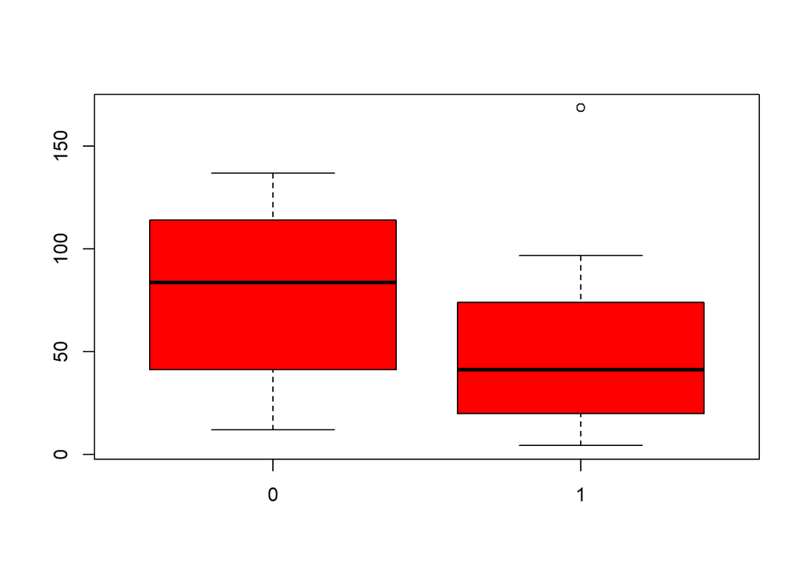

0 : traitement medical aux corticoide

1 : sonde jj

###### Statistiques de la clearence de la creatine des patients ayant recu le traitement medical aux corticoide :

Min. : 11.84  
1st Qu.: 44.22  
Median : 83.48  
Mean : 78.74  
3rd Qu.:113.50 Max. :136.73

Ces 20 patients ont une valeur comprise entre 11.84 et 136.73 avec une moyenne de 78.74

##### Statistiques de la clearence de la creatine des patients traitÃ©s Ã la sonde jj :

Min. : 4.24 1st Qu.: 21.05 Median : 41.20  
Mean : 51.99  
3rd Qu.: 73.41  
Max. :168.53

### Effets sur l’Hydronephrose

Chez les patients ayant recu le traitement aux corticoides, l’hydronephrose est detecté dans 40% des cas contre 95% pour ceux traités Ã la sonde.